# Assignment 10

WADDS

March 22, 2018

## Team

We found that in general, questions containing obscene amounts of question marks had lower scores overall. We also found that the more code characters within a question, the lower score it got as well. We also found that the longer the question was, the lower the score. This makes sense since most people may not want to read a long question, but rather get straight to the answer. Finally, we found that the more “ing” verbs the question contained, the lower the score. This could be because open-ended questions such as “how” allow for more options that more specific questions about using certain functions.

## Sarah

### Questions

I chose to analyze the number of question marks in each question. This will give an idea of how many different aspects of a single problem each post is asking about. It will be interesting to see whether more questions result in more specificity and therefore higher ratings, or if they result in more confusion and lower ratings.

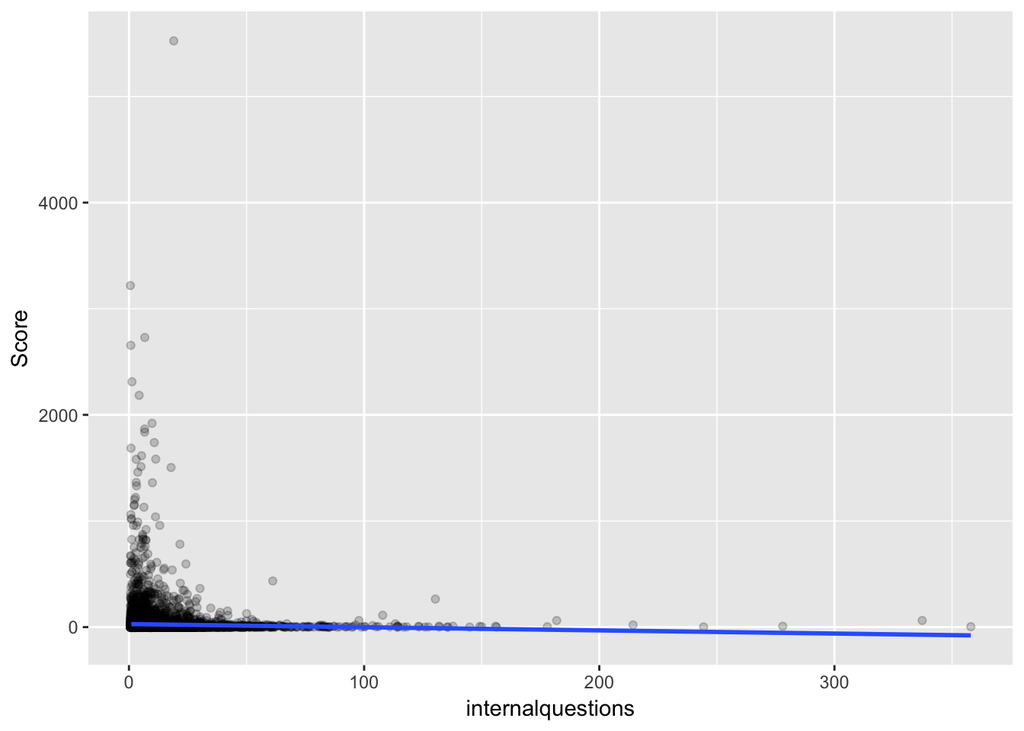

There are some questions with an absurdly large number of question marks in them. The scores tend to be lower the more question marks there are; however, I will examine the trends in the majority of the data points by filtering out those with very high scores or those with very high numbers of question marks.

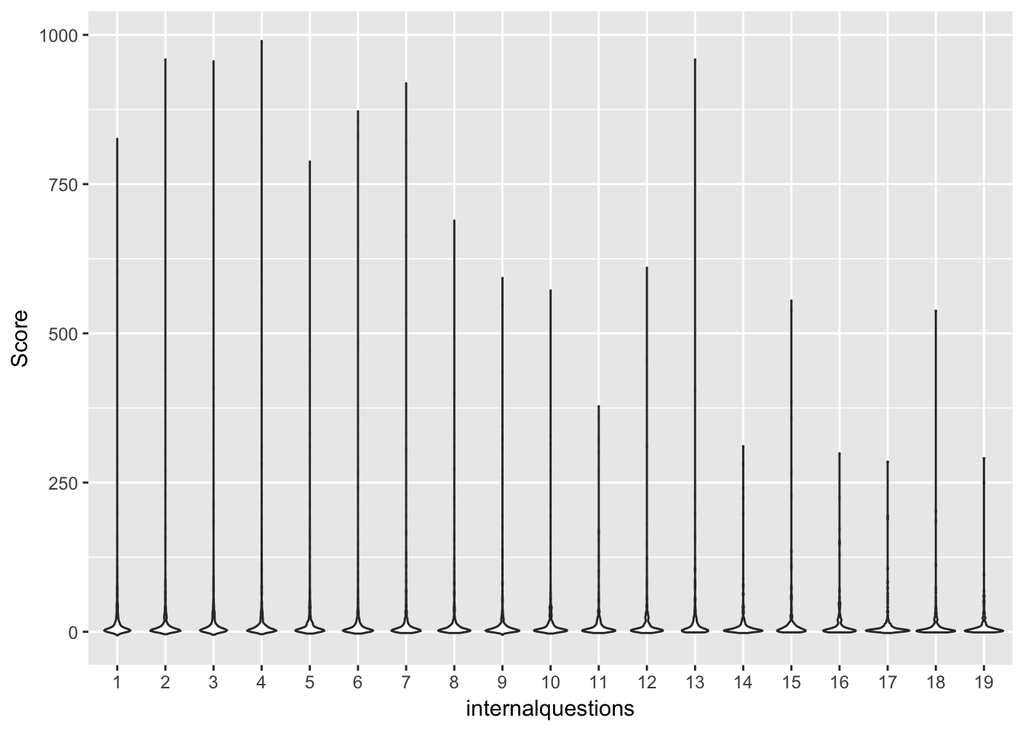

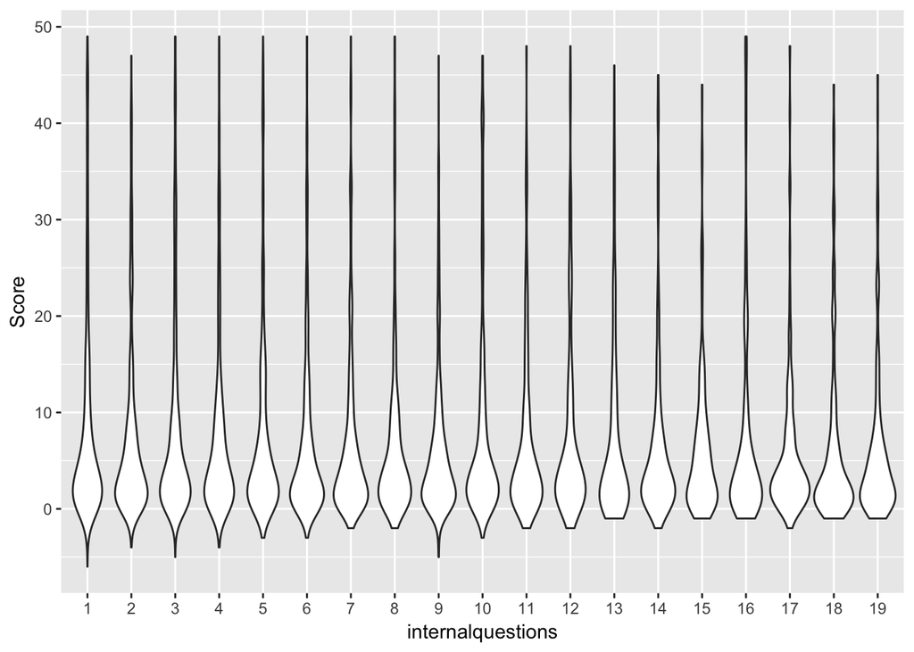

There don’t seem to be any noticable trends in the most common numbers of question marks within a question and their scores.

### Answers

I chose to analyze how many paragraphs an answer has and what relationship that might have with the scores an answer received. Exploring this will allow us to see if breaking an answer into more pargraphs and writing a long enough answer that requires paragraphs results in higher scores, or if more succinct answers tend to do better.

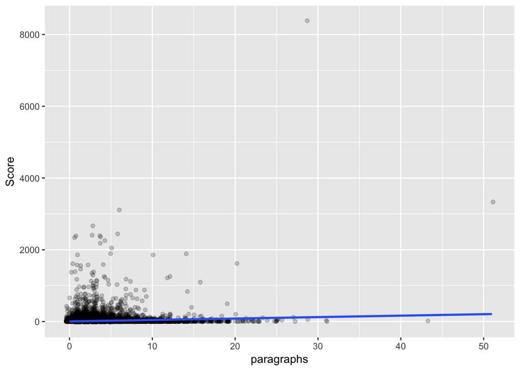

From this plot, it appears that there are some anwers with absurdly large scores and number of paragraphs that are making it difficult to see the general trend of the majority of the dataset, so I will filter those out so we can look at the patterns of the more commons scores and paragraph numbers.

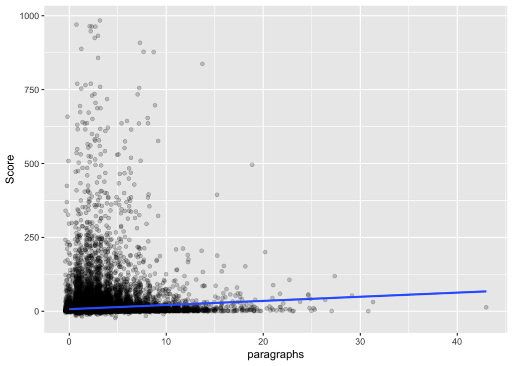

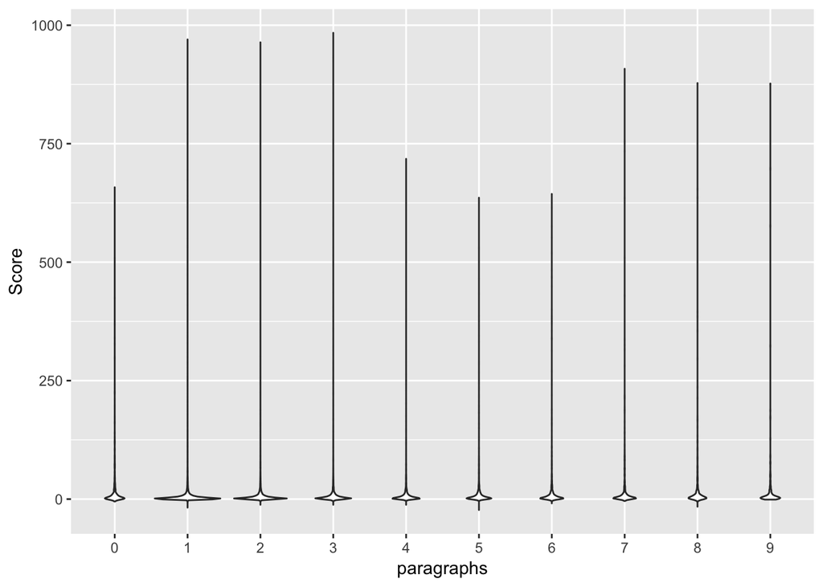

## Simple rules to judge a question

We are curious about what make the question or answer in the dataset to be a good/bad one.

Straightforwardly, we find two coarse features, *i.e.* the length of the title and body of the questions.

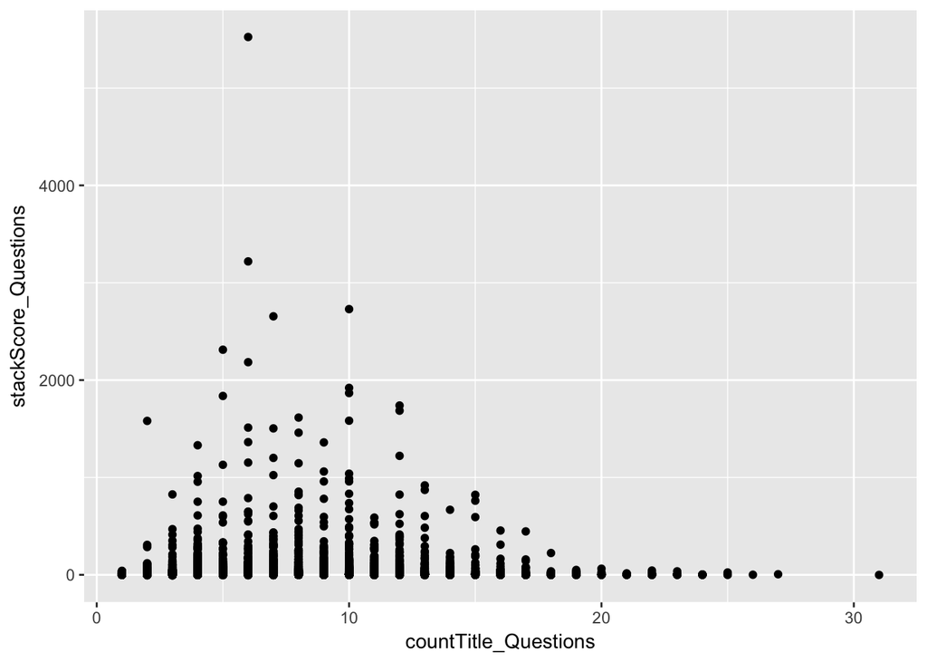

```r
stackQuestions <- read.csv("Questions_trunc.csv",header= TRUE, sep = ",")
stackScore_Questions <- stackQuestions$Score
countBody_Questions <- sapply(gregexpr("\\W+", stackQuestions$Body), length)
countTitle_Questions <- sapply(gregexpr("\\W+", stackQuestions$Title), length)

df <- data.frame(countTitle_Questions, stackScore_Questions)
df2 <- data.frame(countBody_Questions, stackScore_Questions)


ggplt <- ggplot(df, aes(x = countTitle_Questions, y = stackScore_Questions)) + geom_point()

ggplt2 <- ggplot(df, aes(x = countBody_Questions, y = stackScore_Questions)) + geom_point()



ggplt
```

It coincides with our first thought, a good question is with a balanced length of title.

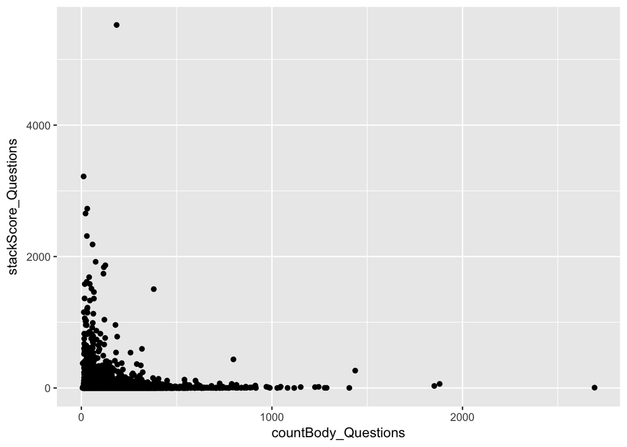

On the other side, from the graph above, we can draw the conclusion that the quanlity of a question has a negative correction with the length of body of the question.

But the feature is too coarse to character how to be a good question.

## Simple rules to judge an answer

Intuitively, the answer is too long or, too short, it may not be good enough.

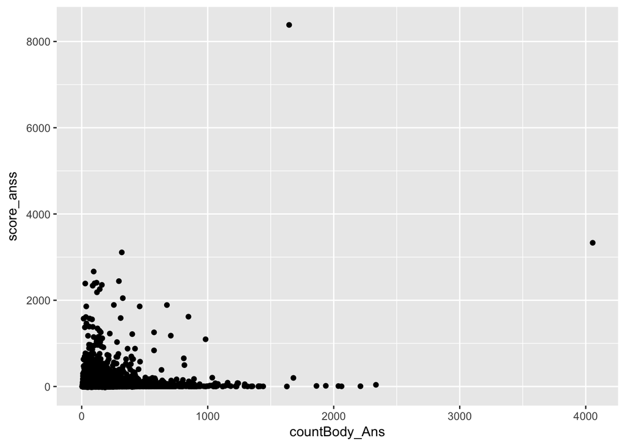

```r
stackAnss <- read.csv("Answers_trunc.csv", header = TRUE, sep = ",")
score_anss <- stackAnss$Score
countBody_Ans <- sapply(gregexpr("\\W+", stackAnss$Body), length)
df3 <- data.frame(countBody_Ans, score_anss)

ggplt3 <- ggplot(df3, aes(x = countBody_Ans, y = score_anss)) + geom_point()
ggplt3
```

From the plot, we can see most of the answers are less than 1000 words. From practical point of view, too long meeans impatience. So a balanced length of the answer can improve the quality of the answer. Elegancy and simpleness can earn a good score.

But again this feature is too coarse to character how to be a good answer.

## Derek

```
##        Id           OwnerUserId       CreationDate
##  Min.   :    497   Min.   :      1   Min.   :2008-08-02 16:56:53
##  1st Qu.: 547469   1st Qu.:  12855   1st Qu.:2009-02-13 20:07:34
##  Median : 996242   Median :  42221   Median :2009-06-15 13:51:54
##  Mean   : 983809   Mean   :  75139   Mean   :2009-05-26 12:30:07
##  3rd Qu.:1443283   3rd Qu.:  97828   3rd Qu.:2009-09-18 08:41:26
##  Max.   :1841853   Max.   :5696608   Max.   :2009-12-03 18:21:27
##                    NA's   :1076
##     ParentId           Score             Body             numOfCode
##  Min.   :    469   Min.   : -23.00   Length:40000       Min.   : 0.000
##  1st Qu.: 513291   1st Qu.:   1.00   Class :character   1st Qu.: 0.000
##  Median : 959675   Median :   2.00   Mode  :character   Median : 1.000
##  Mean   : 956609   Mean   :  12.82                      Mean   : 1.654
##  3rd Qu.:1416921   3rd Qu.:   7.00                      3rd Qu.: 2.000
##  Max.   :1841737   Max.   :8384.00                      Max.   :76.000
##
##   numOfSpecial
##  Min.   :   0.00
##  1st Qu.:   9.00
##  Median :  21.00
##  Mean   :  41.03
##  3rd Qu.:  48.00
##  Max.   :6930.00
##
```

```
##        Id           OwnerUserId       CreationDate
##  Min.   :    469   Min.   :     26   Min.   :2008-08-02 15:11:16
##  1st Qu.: 494725   1st Qu.:  18426   1st Qu.:2009-01-30 06:54:34
##  Median : 866408   Median :  51197   Median :2009-05-14 23:38:29
##  Mean   : 836884   Mean   :  90303   Mean   :2009-04-23 20:37:54
##  3rd Qu.:1192890   3rd Qu.: 103532   3rd Qu.:2009-07-28 09:12:32
##  Max.   :1513592   Max.   :3431280   Max.   :2009-10-03 12:14:31
##                    NA's   :949
##      Score            Title               Body             numOfCode
##  Min.   :  -6.00   Length:10000       Length:10000       Min.   : 0.000
##  1st Qu.:   1.00   Class :character   Class :character   1st Qu.: 0.000
##  Median :   4.00   Mode  :character   Mode  :character   Median : 1.000
##  Mean   :  25.35                                         Mean   : 1.582
##  3rd Qu.:  12.00                                         3rd Qu.: 2.000
##  Max.   :5524.00                                         Max.   :38.000
##
##   numOfSpecial
##  Min.   :   0.00
##  1st Qu.:  12.00
##  Median :  29.00
##  Mean   :  58.37
##  3rd Qu.:  68.00
##  Max.   :2141.00
##
```

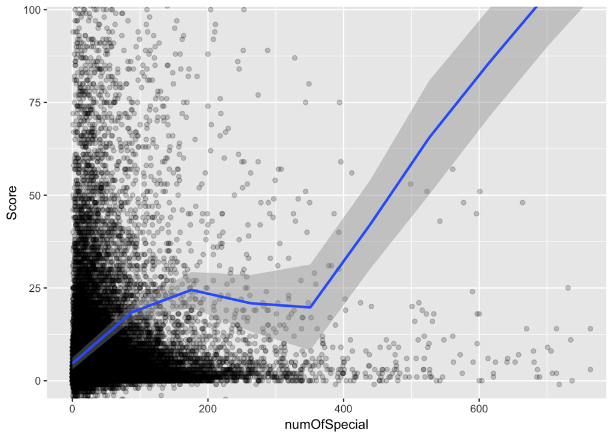

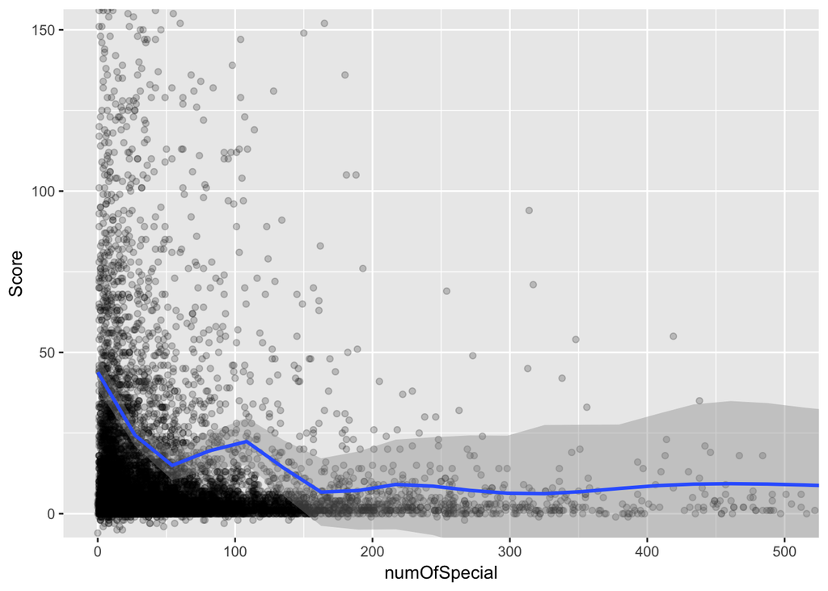

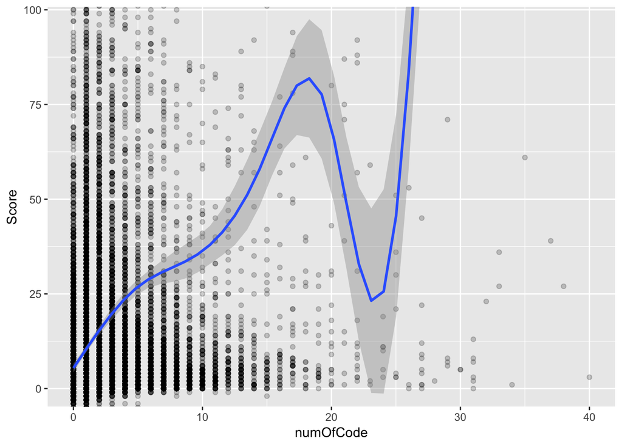

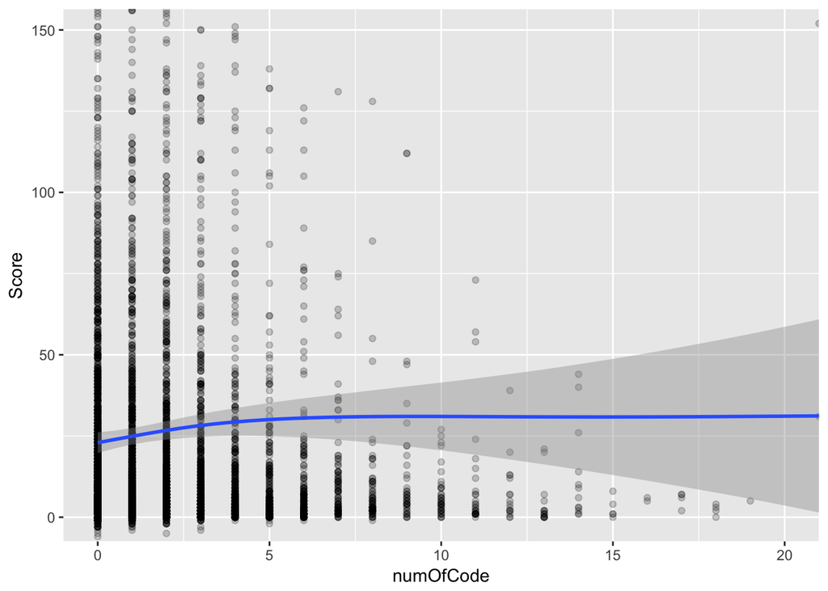

## David

```
## # A tibble: 6 x 2
##   word       sentiment
##   <chr>      <chr>
## 1 2-faced    negative
## 2 2-faces    negative
## 3 a+         positive
## 4 abnormal   negative
## 5 abolish    negative
## 6 abominable negative
```

```
## # A tibble: 6 x 2
##      Id sentiment
##   <int>     <dbl>
## 1   469      0
## 2   502      0
## 3   535      4.00
## 4   594      0
## 5   683      0
## 6   742     -2.00
```

```
## # A tibble: 6 x 2
##      Id sentiment
##   <int>     <dbl>
## 1   497     -1.00
## 2   518      1.00
## 3   536      0
## 4   538     -1.00
## 5   541      2.00
## 6   595      2.00
```

Here, I have defined a variable called sentiment score for both of questions and answers as feature, and this variable will be used to find the relationship between created feature and score in question/answers data. The sentimet score is computed by number of positive words minus number of negative words.

# Relationship between created feature and score in questions/answers data:

I have created two plots, and the first one is used as finding the relationship between created feature and score in question data, and another one is for the answers data

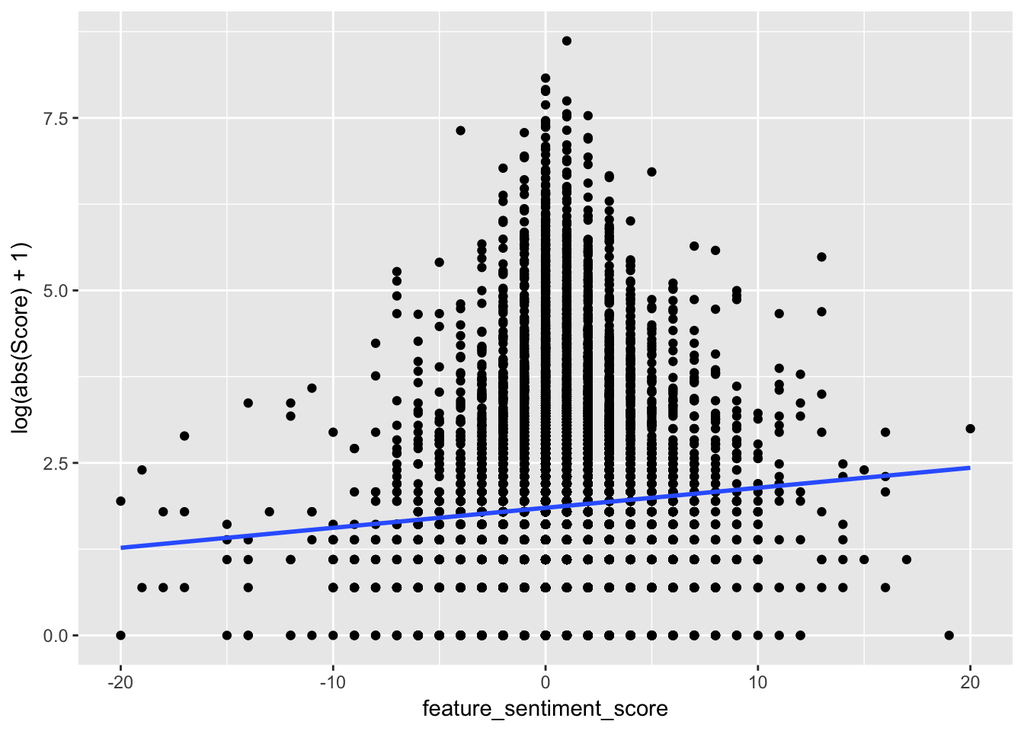

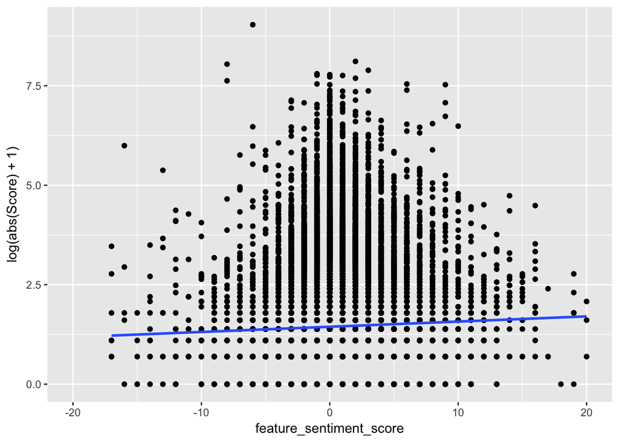

Note here, the sentiment scores are limited into -20 to 20 which drop some outliers and it makes the result more reliable, and here I use log-scale of the score to check relations more obviously, I add 1 to avoid cases where score is 0.

## Abby

I am curious to see if using “ing” verbs in the title of the question increases the score of the question. Since action verbs might imply a more clear answer than a “how” question, there may be a relationship between verbs and higher scores.

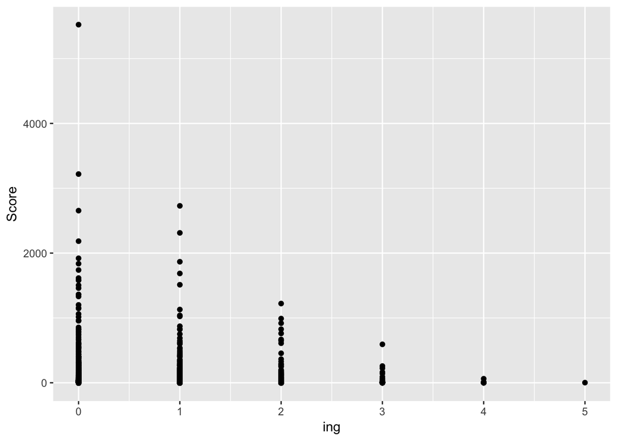

From the plot above, it looks as though there is a slight relationship between the number of “ing” verbs and the questions rating. However, it is not the relationship I was expecting. I thought more ing verbs would correspond to a higher rating, while the opposite seems to be true. This could be explained because of how people approach different questions. When people have preconceived notions of what may be causing a problem it can be harder to help them. Whereas, if a person asks more open-ended questions such as how can… then it can be easier to answer the question, and more specific information may have been provided.

There is also an interesting question as to what makes an answer highly rated or not. I am curious to see if the presence of questions within the answer contribute to a lower rating. More questions may imply a lack of understanding on the part of the person answering. This could lead to an unhelpful answer and thus a lower score.

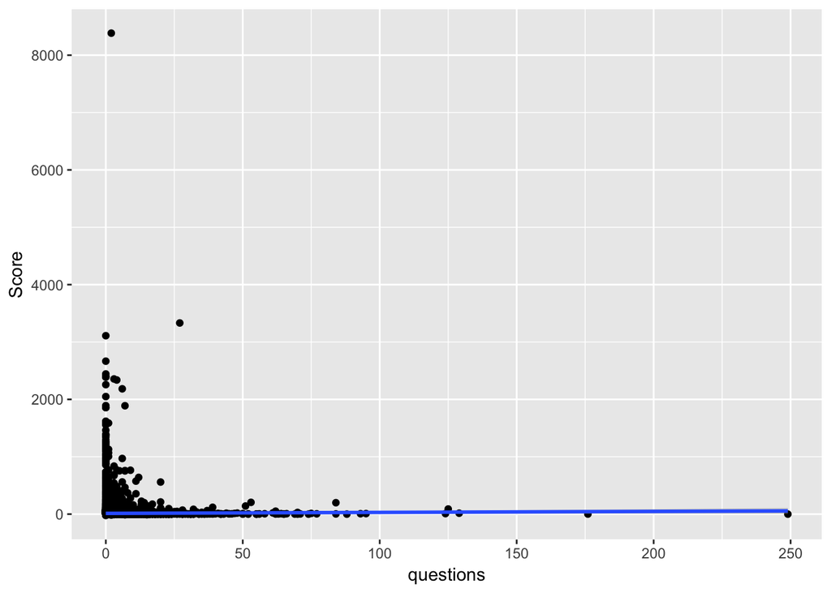

From the plot above, it seems as though the relationship is the opposite of what I was expecting, with the presence of more question marks indicating a higher score for the answer. However, there is an extreme outlier with a score above 8000 that could be skewing the data.

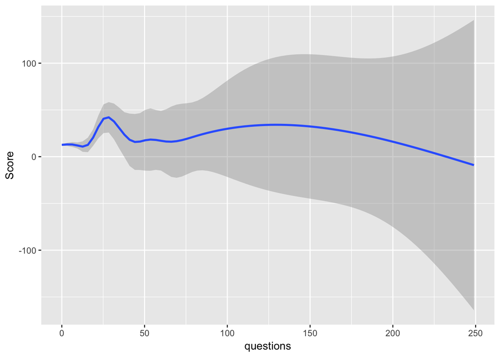

## Summary of Individual Contributions

Sarah: For my individual contribution, I found the number of question marks in the body of each question and the number of paragraphs in the body of each answer, and compared each of these with their score, looking for relationships between the two. I did this to see if longer, more in depth, answers or more broken up answers got higher ratings than simpler ones and to see if more complicated questions got higher or lower ratings.

Derek: I created two features, both looking at code embdedded in the text. One counts special characters (after the html, newlines, and other markup has been removed) as a standin for code (because its counting all the “<>()!=+-:;”, etc.), and the other looks at the number of code tags. The premise being that since these are questions and answers for python, a programming language, answers lots of code maybe better because they are provided larger worked out solutions, and conversely answers may be asking specific or broad questions based on the amount of code they include. I also did a lot of regex text preprocessing as I was playing around with the data.

David: Here, I mainly created a useful feature called sentiment score for both questions and answers. I think this is interesting because we can know that for sometimes, when people ask questions, they need to consider whether it is useful or not. They may also have the similar problems and the score difference of the votes could be very effective for their way of thinkning. From both of the questions and answers plots, I use a same feature which is sentiment score, from the plots, we can find that there are positive relations between the scores and the sentiment scores in both cases as the fitted straight lines show ascend trend, it means that higher sentiment score obtained from the questions or answers, higher score would be obtained.

Will: For this lab, I try to analyze what kinds of questions counts as a good question, and I’m fouces on the length of title and body of the questions. In order to do it, I used the sapply function to figure out the length of title and body of the questions. Next, I created the plot to show the relationship between length of the body of the question and score. Finally, I got that the longer the body of the question, the lower the quality of a question.